# Big Data Final Exam

2024-05-27

# Problem 1

# Part a

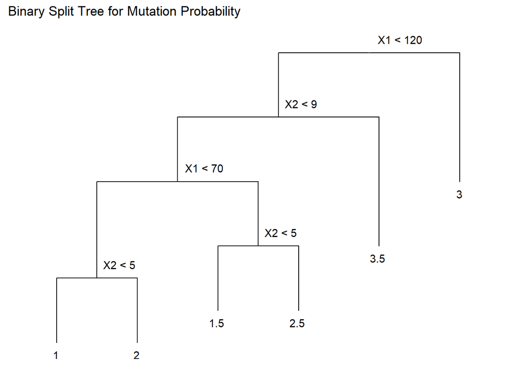

```r
# Define the tree structure
tree_structure <- "((((1:1,2:1):1.5,(1.5:1,2.5:1)A:1)B:1,3.5:2)C:1,3:2)D;"
tree <- ape::read.tree(text = tree_structure)
tree$node.label <- c("X1 < 120", "X2 < 9", "X1 < 70", "X2 < 5", "X2 < 5")

# Plot the tree
ggtree(tree, ladderize = FALSE) +
  geom_tiplab(vjust = 1.8, hjust = 0.6) +
  geom_text2(aes(label = label, subset = !isTip), hjust = -0.2, vjust = -1.1) +
  scale_x_reverse(expand = expansion(mult = c(0.05, 0.1))) +
  coord_flip() +
  ggtitle("Binary Split Tree for Mutation Probability")
```

The figure presents the sketch of the tree. It is interpreted below.

# Part b

# Part c

**Age group effect:** younger age groups (lower x2 values) have lower probabilities of mutations compared to older age groups.

# Part d

No, it is not possible to have a binary split that joins people aged under 24 with radiation received below 120 μSv because the given tree structure and data do not create a single node encompassing both conditions. The splits separate these groups based on different thresholds for age and radiation levels.

# Part e

Growing a bigger tree may not be worth it because it could lead to overfitting, where the model becomes too complex and captures noise in the data rather than the patterns. The current tree already shows the main interactions between age groups and radiation levels, providing a balance between model complexity and interpretability.

# Part f

To place the data points so that the regression model would work better in this particular case, I should ensure that the splits better capture the interaction between age and radiation levels. This might involve adjusting the decision boundaries to align more closely with natural groupings in the data. For instance, adjusting the splits to account for different age groups and radiation to more accurately represent the probability distribution of mutations could help improve the model’s performance.

# Problem 2

# Part a

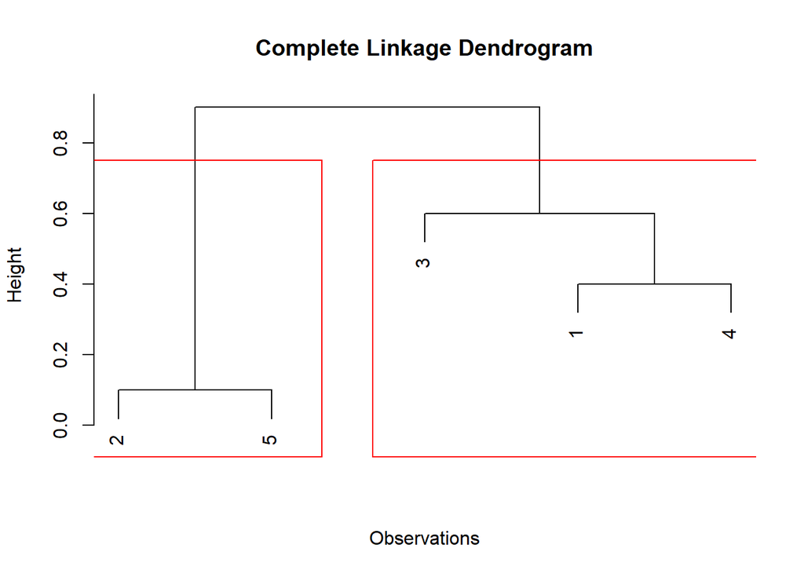

```r
# Define the dissimilarity matrix
dissimilarity_matrix <- matrix(c(
  0, 0.2, 0.6, 0.4, 0.8,
  0.2, 0, 0.3, 0.5, 0.1,
  0.6, 0.3, 0, 0.6, 0.7,
  0.4, 0.5, 0.6, 0, 0.9,
  0.8, 0.1, 0.7, 0.9, 0
), nrow = 5, ncol = 5)

# Convert the matrix to a distance object
dist_obj <- as.dist(dissimilarity_matrix)

# Perform hierarchical clustering using complete linkage
hc_complete <- hclust(dist_obj, method = "complete")

# Perform hierarchical clustering using single linkage
hc_single <- hclust(dist_obj, method = "single")

# Plot dendrogram for complete linkage
plot(hc_complete, main = "Complete Linkage Dendrogram", sub = "", xlab = "Observations", ylab = "Height")
rect.hclust(hc_complete, k = 2, border = "red") # visually indicate clusters
```

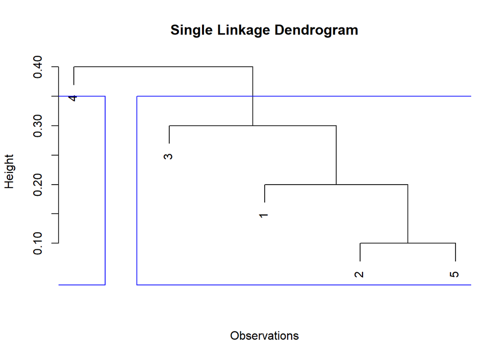

```r
# Plot dendrogram for single linkage
plot(hc_single, main = "Single Linkage Dendrogram", sub = "", xlab = "Observations", ylab = "Height")
rect.hclust(hc_single, k = 2, border = "blue") # visually indicate clusters
```

The first plot represents the **compelte linkage dendrogram** and the second plot shows the **single linkage dendrogram**.

# Part b

**Complete linkage dendrogram:**

If a data scientist wants to have just two clusters, she would need to cut the **complete linkage dendrogram** at a height slightly above 0.8, resulting in two clusters: one with observations 2 and 5, and the other containing observations 1, 3, and 4.

In the **complete linkage dendrogram**, clusters are formed based on the maximum pairwise distance within each cluster, making the clusters more compact. On the other hand, the **single linkage dendrogram** forms clusters based on the minimum pairwise distance, resulting in longer, less compact clusters. This shows how different linkage methods can produce different clustering structures from the same data.

# Part c

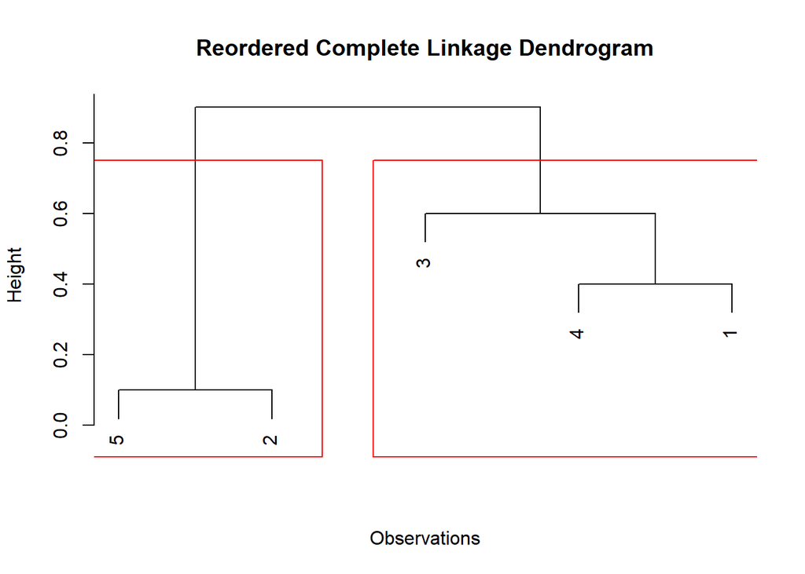

```r
# Convert the matrix to a distance object
dist_obj <- as.dist(dissimilarity_matrix)

# Perform hierarchical clustering using complete linkage
hc_complete <- hclust(dist_obj, method = "complete")

# Perform hierarchical clustering using single linkage
hc_single <- hclust(dist_obj, method = "single")

# Reorder observations for complete linkage dendrogram
hc_complete_reordered <- hc_complete
hc_complete_reordered$labels <- c("4", "5", "3", "1", "2")

# Plot reordered complete linkage dendrogram
plot(hc_complete_reordered, main = "Reordered Complete Linkage Dendrogram", sub = "", xlab = "Observations", ylab = "Height")
rect.hclust(hc_complete_reordered, k = 2, border = "red")
```

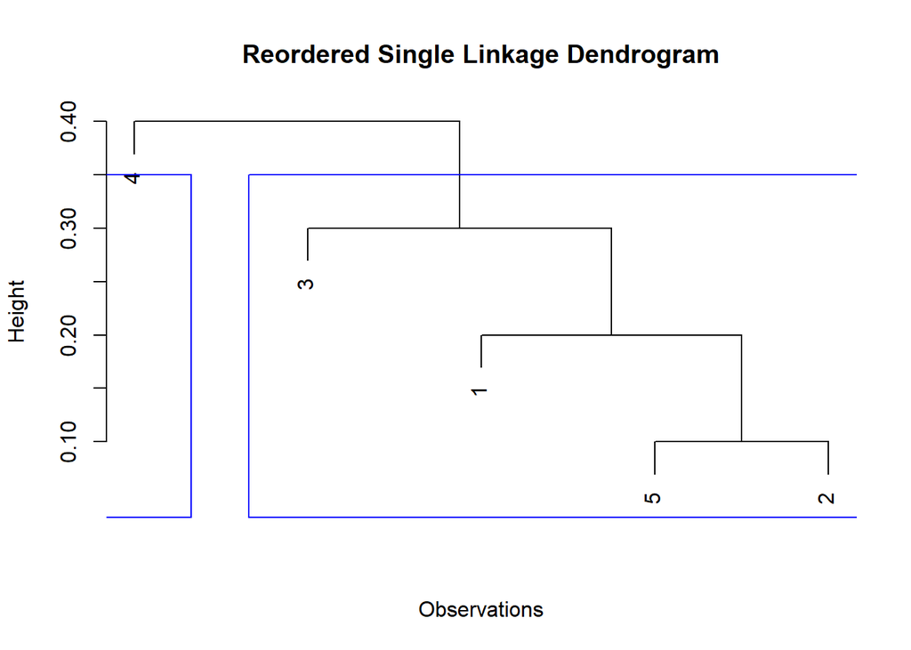

```r
# Reorder observations for single linkage dendrogram
hc_single_reordered <- hc_single
hc_single_reordered$labels <- c("1", "5", "3", "4", "2")

# Plot reordered single linkage dendrogram
plot(hc_single_reordered, main = "Reordered Single Linkage Dendrogram", sub = "", xlab = "Observations", ylab = "Height")
rect.hclust(hc_single_reordered, k = 2, border = "blue")
```

The first plot represents the reordered version of the **compelte linkage dendrogram** and the second plot shows the reordered version of the **single linkage dendrogram**. I repositioned 2 or more leaves in both cases, but the results and interpretations stay the same because I basically only switched places of values which are “on the same level”.

# Problem 3

# Part a

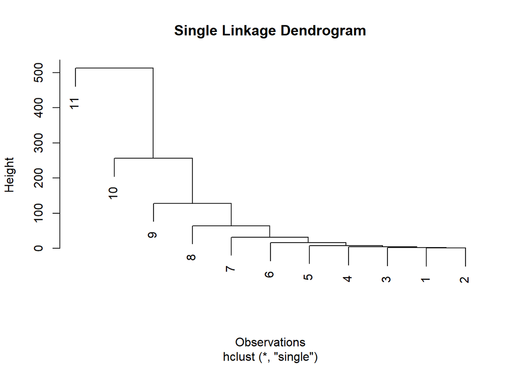

```r
# Generate the exponential phase points
exponential_points <- 2^(0:10)

# Calculate the distance matrix
dist_matrix <- dist(exponential_points)

# Perform hierarchical clustering using single, complete, and average linkage
hc_single <- hclust(dist_matrix, method = "single")
hc_complete <- hclust(dist_matrix, method = "complete")
hc_average <- hclust(dist_matrix, method = "average")

# Single linkage dendrogram
plot(hc_single, main = "Single Linkage Dendrogram", xlab = "Observations", ylab = "Height")
```

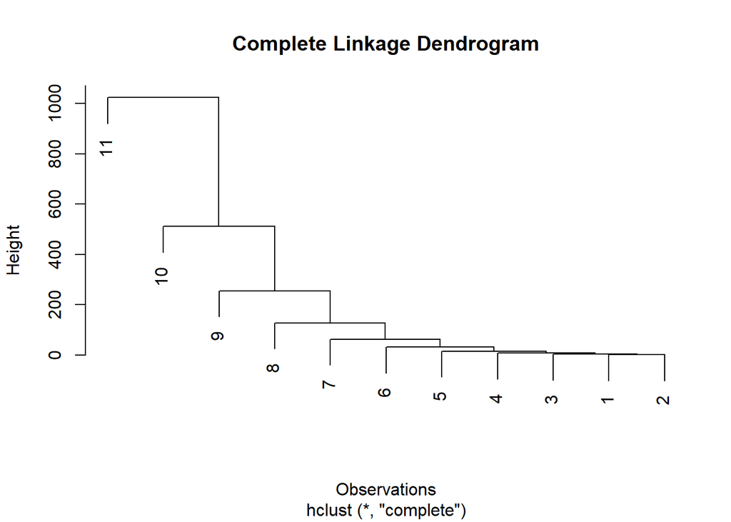

```r
# Complete linkage dendrogram
plot(hc_complete, main = "Complete Linkage Dendrogram", xlab = "Observations", ylab = "Height")
```

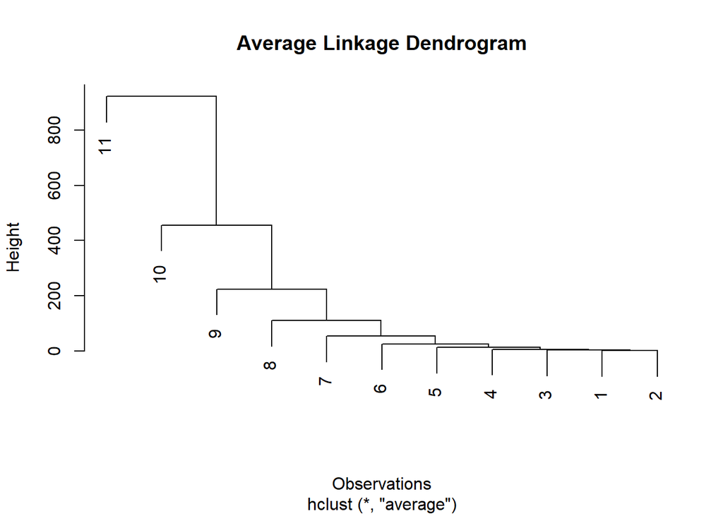

```r
# Average linkage dendrogram
plot(hc_average, main = "Average Linkage Dendrogram", xlab = "Observations", ylab = "Height")
```

The dendrograms for single, complete, and average linkage methods show the hierarchical clustering of the exponential phase points from 2^0 to 2^10.

All dendrograms appear similar in structure but differ in the scale of merging distances due to the different linkage criteria used.

# Part b

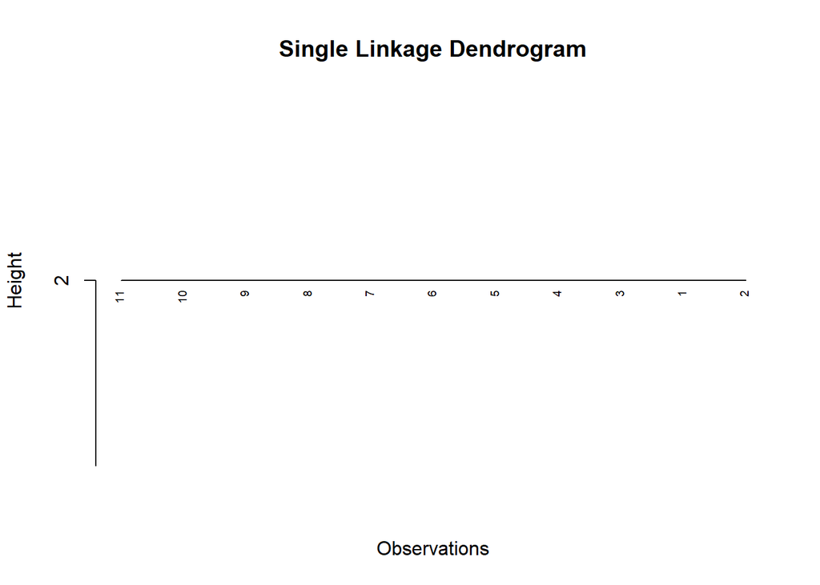

```r
# Define the new dissimilarity function
diss <- function(x) {
  dist_mat <- as.matrix(dist(x))
  n <- length(x)
  new_diss <- matrix(0, n, n)
  for (i in 1:(n-1)) {
    for (j in (i+1):n) {
      new_diss[i, j] <- new_diss[j, i] <- max(x[i], x[j]) / min(x[i], x[j])
    }
  }
  as.dist(new_diss)
}

# The data points
data_points <- 2^(0:10)

# Calculate the dissimilarity matrix using the new function
diss_matrix <- diss(data_points)

# Perform hierarchical clustering using single, complete, and average linkage
single_linkage <- hclust(diss_matrix, method = "single")
complete_linkage <- hclust(diss_matrix, method = "complete")
average_linkage <- hclust(diss_matrix, method = "average")

# Plot the dendrograms
plot(single_linkage, main = "Single Linkage Dendrogram", xlab = "Observations", sub = "", cex = 0.6)
```

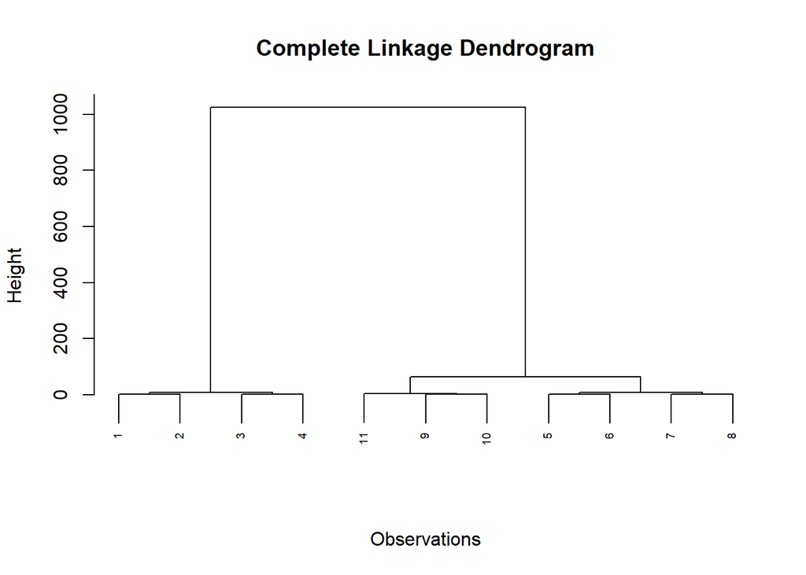

```r
plot(complete_linkage, main = "Complete Linkage Dendrogram", xlab = "Observations", sub = "", cex = 0.6)
```

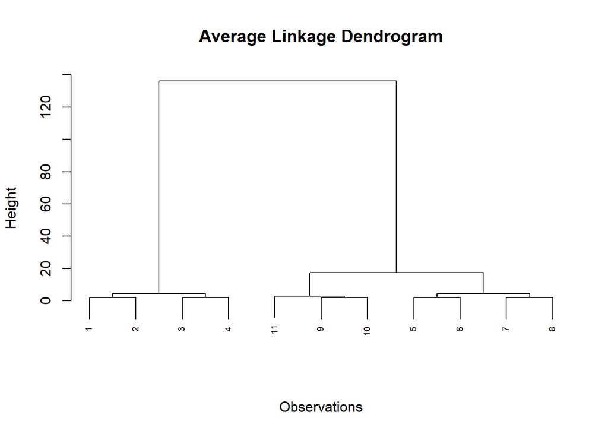

```r
plot(average_linkage, main = "Average Linkage Dendrogram", xlab = "Observations", sub = "", cex = 0.6)
```

- In the **single linkage dendrogram**, the clustering merges points sequentially, resulting in a flat appearance because the max-min dissimilarity function doesn’t show distinct clusters clearly. The appearance of the single linkage dendrogram may have occurred because of the max-min dissimilarity function, making clusters appear less distinct.
- The **complete linkage dendrogram** shows two main clusters, grouping observations 1-4 separately from 5-8 and 9-11.
- The **average linkage dendrogram** also shows two main clusters but with different height values as they are much higher in the previous case.

Overall, all of the dendrograms look very different from the ones in part A due to the new methodology.